# Ghana Agricultural Profits Analysis Steps and Explanations

Group 07 - Siqi Zhang, Huibo Jia, Qiyu Ye, Mark Russeff

12-06-2018

## Read data

After reading through the documentation, we determined these data files contain the data we want to use to analyze the influencing factors of Ghana agricultural profits

```r
# list of data file pairs to read, first is subfolder, second is file name
datafiles <- list(c("aggregates/", "agg2"),
                  c("", "sec8b"),
                  c("", "sec0a"),
                  c("", "sec1"),
                  c("", "sec2a"),
                  c("", "sec8a2"),
                  c("", "sec8a3"),
                  c("", "sec8c1"),
                  c("", "sec8c2"),
                  c("community/", "cs2"))
invisible(sapply(datafiles, readRawData))
```

## Calculate agricultural profit per area unit

First we need to convert different area unit into a same one. Looking at count of each unit, acre is the major one, so we decide to map other units to acre. According to G4USERSG.pdf, we create a map between each unit to a multiplier of it when it’s converted to acre (the “Other” unit is treated as NA). Then join the map onto `sec8b` and multiply with original land size to get unified land size (values greater than 1e+100 are treated as NA). We noticed that some households have multiple entries of land size info and among them there is NA value. So we convert NA to 0 so we can sum up land size for each household. Eventually, household with land size less than 0.5 acre are filtered out because that’s probably not a real farm.

| Area unit | To Acre |
| --- | --- |
| 1 Acre | 1 Acre |
| 1 Poles | 1 Acre |
| 1 Ropes | 1/9 Acre |
| Other | NA |

```r
# map land size units to acre with a multiplier (s8bq4bm)
# the "Other" unit is treated as NA
table(sec8b$s8bq4b)
```

```
                    1                     2                     3
                 7725                  1477                  1354
                    4 1.74980057982641e+100
                   13                     1
```

```r
land_size_unit_map <- data.frame("s8bq4b" = as.double(c(1:4)),
                                 "s8bq4bm" = c(1, 1, 1/9, NA))
# convert all land size to acre
land_size_info <- sec8b %>%
  select(clust, nh, s8bq4a, s8bq4b) %>%
  mutate(s8bq4a = ifelse(s8bq4a > 1e+100, NA, s8bq4a),
         s8bq4b = ifelse(s8bq4b > 1e+100, NA, s8bq4b)) %>%
  left_join(land_size_unit_map) %>%
  # s8bq4ac is corrected s8bq4a, which is land size in acre
  mutate(s8bq4ac = s8bq4a * s8bq4bm) %>%
  # convert NA to 0 to calculate sum of land size for each household
  replace(., is.na(.), 0) %>%
  group_by(clust, nh) %>%
  summarise(landSize = sum(s8bq4ac)) %>%
  # remove household with small land size
  filter(landSize >= 0.5)
```

Then we use agricultural income minus depreciation of farm equipment (`agri1 - hhagdepn`) as household profit, and devide it by household land size to get profit per area unit. `agg2` does not have NA value so no need to clean up.

```r
# identify count of NAs in agg2
colSums(is.na(agg2))
```

```
   clust       nh    agri1   agri1c    agri2   agri2c hhagdepn
       0        0        0        0        0        0        0
```

```r
# check correlation between agricultural income and corrected agricultural income
cor(agg2$agri1, agg2$agri1c)
```

```
[1] 1
```

```r
# resolve warnings during join
attr(agg2$clust, "label") <- "Enumeration Area number"
attr(agg2$nh, "label") <- "Household ID"
# calculate household agri profit per acre
# because the above correlations are both 1,
# use only "agri1" to calculate agricultural profit
hh_profit_info <- agg2 %>%
  select(clust, nh, agri1, hhagdepn) %>%
  filter(agri1 != 0) %>%
  inner_join(land_size_info, by = c("clust", "nh")) %>%
  mutate(profit = (agri1 - hhagdepn) / landSize) %>%
  select(-agri1, -hhagdepn, -landSize)
attr(hh_profit_info$profit, "label") <- "HH agri profit"
```

## Tidy household basic information

For basic household information, we are interested in language of respondent (values greater than 1e+100 are treated as “Unknown” language), ecological zone number and 3 different locality classifications. All variables are converted to factor type so they could be used as dummy variables in linear model.

```r
# household basic information
hh_basic_info <- sec0a %>%
  select(region, district, eanum, clust, nh, reslan, ez:loc3) %>%
  mutate(reslan = cleanAndFactorize(reslan, 1e+100, 99,
                                    levels = as.character(c(1:8, 99)),
                                    labels = c("English", "Akan", "Ewe", "GaAdangbe",
                                               "Dagbani", "Hausa", "Nzema", "Other", "Unknown")),
         ez = factor(ez,
                     levels = as.character(c(1:3)),
                     labels = c("Coastal", "Forest", "Savannah")),
         loc2 = factor(loc2,
                       levels = as.character(c(1,2)),
                       labels = c("Urban", "Rural")),
         loc5 = factor(loc5,
                       levels = as.character(c(1:5)),
                       labels = c("Accra", "OtherUrban", "RuralCoastal",
                                  "RuralForest", "RuralSavannah")),
         loc3 = factor(loc3,
                       levels = as.character(c(1:3)),
                       labels = c("Accra", "OtherUrban", "Rural"))
  )
```

## Tidy household member information

We picked some data about household members such as sex, age and education and aggregate them on household level to analyze the effect of variety of household members on agricultural profit.

Select household members sex and age information and calculate mean, max and min age of household. The relation (`rel`) data is used to filter by head of household later.

```r
# household member information
hhm_info <- sec1 %>%
  select(clust, nh, pid, sex, agey, rel) %>%
  group_by(clust, nh) %>%
  mutate(female = sex == 2,
         age = agey,
         avgAge = mean(agey),
         maxAge = max(agey),
         minAge = min(agey)
  ) %>%
  select(-sex, -agey)
```

For education data, we categorize educational qualification (`s2aq3`) into 5 levels: “None”, “BasicEducation”, “SecondaryEducation”, “TertiaryEducation” and “Other”, based on information from the two sources below. For missing value in `s2aq3`, it’s because these people never attended school (`s2aq1 == 2`). In this case we set education to None.

[Education System in Ghana](https://www.scholaro.com/pro/Countries/Ghana/Education-System)

[Education in Ghana Wikipedia](https://en.wikipedia.org/wiki/Education_in_Ghana)

| Educational Qualification | Education Level |
| --- | --- |
| 01 None | None |
| 02 MSLC?BECE | BasicEducation |
| 03 Voc/Comm | SecondaryEducation |
| 04 ‘O’ Level | SecondaryEducation |
| 05 SSS | SecondaryEducation |
| 06 ‘A’ Level | SecondaryEducation |
| 07 T/T Cert. B | TertiaryEducation |
| 08 T /T Cert. A | TertiaryEducation |
| 09 Nursing | TertiaryEducation |
| 10 Tech/Prof Cert. | TertiaryEducation |
| 11 Tech/Prof Dip | TertiaryEducation |
| 12 Bachelor | TertiaryEducation |
| 13 Masters | TertiaryEducation |
| 14 Doctorate | TertiaryEducation |
| 96 Other | Other |

```r
# household member education information
# map education qualification to education level
educ_level_map <- data.frame("s2aq3" = c(1:14, 96),
                             "s2aq3l" = c(1, 2, rep(3, 4), rep(4, 8), 5))
# resolve warnings
attr(educ_level_map$s2aq3, "label") <- "Highest educ qualification"
attr(educ_level_map$s2aq3, "format.stata") <- "%10.0g"
# Check NAs
colSums(is.na(sec2a))
```

```
     nh     pid   s1q23   clust   s2aq1   s2aq2   s2aq3   s2aq4  s2aq5a
      0       0       0       0       0       0       0       0       0
 s2aq5b   s2aq6   s2aq7   s2aq8   s2aq9  s2aq10  s2aq11  s2aq12  s2aq13
      0       0       0       0       0       0       0       0       0
s2aq13a  s2aq14  s2aq15  s2aq16  s2aq17
      0       0       0       0       0
```

```r
hhm_educ <- sec2a %>%
  select(clust, nh, pid, s2aq1, s2aq3) %>%
  # if never attended school (s2aq1 == 2), set education to None (s2aq3 = 1)
  mutate(s2aq3 = ifelse(s2aq1 == 2, 1, s2aq3)) %>%
  left_join(educ_level_map) %>%
  mutate(educ = factor(s2aq3l,
                       levels = as.character(c(1:5)),
                       labels = c("None", "BasicEducation", "SecondaryEducation",
                                  "TertiaryEducation", "Other"))) %>%
  select(-s2aq1, -s2aq3, -s2aq3l)
```

Then we join household member info and education info, and use data from head of household (`rel == 1`) as a representative of the household.

```r
hh_head_info <- hhm_info %>%
  inner_join(hhm_educ, by=c("clust", "nh", "pid")) %>%
  filter(rel == 1) %>% # head of household
  select(-pid, -rel)
```

## Tidy agricultural characteristics information

We included agricultural characteristics information in our analysis as well, includign Livestock and Fishing (`sec8a2`), Agricultural equipment (`sec8a3`) and Crops (`sec8c1` and `sec8c2`). We would like to see if any certain types of livestock, equipment and/or crop would contribute a lot to profit.

For livestock data, we found that there are too many missing values (value greater than 1e+100) in its unit of messaure (`s8aq22b`). So we decided to spread livestock count by livestock type so that each livestock type is a column with the count as its value, and assume same livestock type has same unit of messaure so we can compare accros them. We also created a column for the count of different livestock types each household owns.

```r
table(sec8a2$s8aq22b)
```

```
                    1                     2                     3
                   32                    41                    22
                    4 1.74980057982641e+100
                   30                  4716
```

```r
# spread livestock count and count livestock type
# since there are too many missing value in livestock unit of messaure (s8aq22b),
# we assume same livestock type has same unit,
# and we only take livestock count (s8aq22a) into consideration
hh_livestock_info <- sec8a2 %>%
  select(clust, nh, livstcd, s8aq22a) %>%
  group_by(clust, nh) %>%
  mutate(livstcdTypeCount = n()) %>%
  spread(key = livstcd,
         value = s8aq22a,
         fill = 0,
         sep = "")
summary(hh_livestock_info)
```

```
     clust            nh        livstcdTypeCount    livstcd1
 Min.   :4002   Min.   : 1.00   Min.   :1.00     Min.   :0.0000
 1st Qu.:4395   1st Qu.: 6.00   1st Qu.:1.00     1st Qu.:0.0000
 Median :4589   Median :11.00   Median :2.00     Median :0.0000
 Mean   :4580   Mean   :10.79   Mean   :2.13     Mean   :0.1205
 3rd Qu.:4855   3rd Qu.:16.00   3rd Qu.:3.00     3rd Qu.:0.0000
 Max.   :4999   Max.   :25.00   Max.   :7.00     Max.   :9.0000
    livstcd2          livstcd3          livstcd4          livstcd5
 Min.   : 0.0000   Min.   :      0   Min.   :      0   Min.   : 0.0000
 1st Qu.: 0.0000   1st Qu.:      0   1st Qu.:      0   1st Qu.: 0.0000
 Median : 0.0000   Median :      0   Median :      1   Median : 0.0000
 Mean   : 0.8517   Mean   :    464   Mean   :   1178   Mean   : 0.6881
 3rd Qu.: 0.0000   3rd Qu.:      3   3rd Qu.:      5   3rd Qu.: 0.0000
 Max.   :90.0000   Max.   :1050000   Max.   :2670000   Max.   :36.0000
    livstcd6        livstcd7           livstcd8          livstcd9
 Min.   :0.000   Min.   :     0.0   Min.   :  0.000   Min.   : 0.00000
 1st Qu.:0.000   1st Qu.:     1.0   1st Qu.:  0.000   1st Qu.: 0.00000
 Median :0.000   Median :     6.0   Median :  0.000   Median : 0.00000
 Mean   :0.022   Mean   :   146.1   Mean   :  2.227   Mean   : 0.07787
 3rd Qu.:0.000   3rd Qu.:    12.0   3rd Qu.:  0.000   3rd Qu.: 0.00000
 Max.   :8.000   Max.   :130000.0   Max.   :150.000   Max.   :40.00000
   livstcd10           livstcd11           livstcd12
 Min.   :    0.000   Min.   :  0.00000   Min.   : 0.00000
 1st Qu.:    0.000   1st Qu.:  0.00000   1st Qu.: 0.00000
 Median :    0.000   Median :  0.00000   Median : 0.00000
 Mean   :    9.321   Mean   :  0.06599   Mean   : 0.06247
 3rd Qu.:    0.000   3rd Qu.:  0.00000   3rd Qu.: 0.00000
 Max.   :13000.000   Max.   :100.00000   Max.   :50.00000
```

Similarly we process the agricultural equipment data.

```r
# spread agricultural equipment count and count agricultural equipment type
hh_equip_info <- sec8a3 %>%
  select(clust, nh, eqcdown, s8aq34) %>%
  replace(., . > 1e+100, 0) %>%
  filter(s8aq34 != 0) %>%
  group_by(clust, nh) %>%
  mutate(equipTypeCount = n()) %>%
  spread(key = eqcdown,
         value = s8aq34,
         fill = 0,
         sep = "")
summary(hh_equip_info)
```

```
     clust            nh        equipTypeCount    eqcdown21
 Min.   :4002   Min.   : 1.00   Min.   :1.000   Min.   :0.000000
 1st Qu.:4125   1st Qu.: 6.00   1st Qu.:1.000   1st Qu.:0.000000
 Median :4539   Median :11.00   Median :1.000   Median :0.000000
 Mean   :4481   Mean   :10.71   Mean   :1.142   Mean   :0.003823
 3rd Qu.:4795   3rd Qu.:16.00   3rd Qu.:1.000   3rd Qu.:0.000000
 Max.   :4992   Max.   :25.00   Max.   :4.000   Max.   :1.000000
   eqcdown22         eqcdown31       eqcdown51          eqcdown61
 Min.   :0.00000   Min.   :0.000   Min.   :  0.0000   Min.   :0.0000
 1st Qu.:0.00000   1st Qu.:0.000   1st Qu.:  0.0000   1st Qu.:0.0000
 Median :0.00000   Median :0.000   Median :  0.0000   Median :0.0000
 Mean   :0.03287   Mean   :0.013   Mean   :  0.2378   Mean   :0.0107
 3rd Qu.:0.00000   3rd Qu.:0.000   3rd Qu.:  0.0000   3rd Qu.:0.0000
 Max.   :2.00000   Max.   :2.000   Max.   :160.0000   Max.   :1.0000
   eqcdown62          eqcdown63          eqcdown64        eqcdown65
 Min.   :  0.0000   Min.   :  0.0000   Min.   :0.0000   Min.   :  0.000
 1st Qu.:  0.0000   1st Qu.:  0.0000   1st Qu.:0.0000   1st Qu.:  1.000
 Median :  0.0000   Median :  0.0000   Median :0.0000   Median :  3.000
 Mean   :  0.2791   Mean   :  0.6017   Mean   :0.0107   Mean   :  3.993
 3rd Qu.:  0.0000   3rd Qu.:  0.0000   3rd Qu.:0.0000   3rd Qu.:  4.000
 Max.   :130.0000   Max.   :236.0000   Max.   :7.0000   Max.   :800.000
```

For crop data, we noticed that some households have multiple entries of same crop type. So we need to group by household and crop type and sum up across same crop type.

```r
# spread household havested crop count and count havested crop type
# some households have multiple entries of same crop type, for example:
(sec8c1 %>% select(clust, nh, cropcd, s8cq3a))[c(377, 378),]
```

| clust | nh | cropcd | s8cq3a |
| --- | --- | --- | --- |
| 4049 | 18 | 1 | 10.0 |
| 4049 | 18 | 1 | 0.5 |

```r
# so need to sum up quantity of same crop type
hh_crop_info <- sec8c1 %>%
  select(clust, nh, cropcd, s8cq3a) %>%
  replace(., . > 1e+100, 0) %>%
  group_by(clust, nh, cropcd) %>%
  # sum up quantity of same crop type
  summarise(s8cq3ac = sum(s8cq3a)) %>%
  group_by(clust, nh) %>%
  mutate(cropTypeCount = n()) %>%
  spread(key = cropcd,
         value = s8cq3ac,
         fill = 0,
         sep = "")
summary(hh_crop_info)
```

```
     clust            nh        cropTypeCount      cropcd0
 Min.   :4002   Min.   : 1.00   Min.   :1.000   Min.   : 0.000000
 1st Qu.:4392   1st Qu.: 6.00   1st Qu.:1.000   1st Qu.: 0.000000
 Median :4572   Median :11.00   Median :2.000   Median : 0.000000
 Mean   :4560   Mean   :10.83   Mean   :2.012   Mean   : 0.003218
 3rd Qu.:4819   3rd Qu.:16.00   3rd Qu.:3.000   3rd Qu.: 0.000000
 Max.   :4999   Max.   :25.00   Max.   :7.000   Max.   :12.000000
    cropcd1           cropcd2             cropcd3
 Min.   :  0.000   Min.   :  0.00000   Min.   :0.0000000
 1st Qu.:  0.000   1st Qu.:  0.00000   1st Qu.:0.0000000
 Median :  0.000   Median :  0.00000   Median :0.0000000
 Mean   :  3.781   Mean   :  0.06846   Mean   :0.0008045
 3rd Qu.:  0.000   3rd Qu.:  0.00000   3rd Qu.:0.0000000
 Max.   :800.000   Max.   :227.80000   Max.   :3.0000000
    cropcd4            cropcd5            cropcd6
 Min.   :   0.000   Min.   :0.000000   Min.   :  0.00000
 1st Qu.:   0.000   1st Qu.:0.000000   1st Qu.:  0.00000
 Median :   0.000   Median :0.000000   Median :  0.00000
 Mean   :   9.701   Mean   :0.002145   Mean   :  0.03433
 3rd Qu.:   0.000   3rd Qu.:0.000000   3rd Qu.:  0.00000
 Max.   : 999.990   Max.   :6.000000   Max.   :125.00000
    cropcd8            cropcd9             cropcd10
 Min.   :  0.0000   Min.   : 0.000000   Min.   :  0.000
 1st Qu.:  0.0000   1st Qu.: 0.000000   1st Qu.:  0.000
 Median :  0.0000   Median : 0.000000   Median :  0.000
 Mean   :  0.5093   Mean   : 0.004023   Mean   :  6.393
 3rd Qu.:  0.0000   3rd Qu.: 0.000000   3rd Qu.:  0.000
 Max.   :999.0000   Max.   :15.000000   Max.   :300.000
    cropcd11           cropcd12           cropcd13           cropcd14
 Min.   : 0.00000   Min.   : 0.00000   Min.   :  0.0000   Min.   :  0.000
 1st Qu.: 0.00000   1st Qu.: 0.00000   1st Qu.:  0.0000   1st Qu.:  0.000
 Median : 0.00000   Median : 0.00000   Median :  0.0000   Median :  0.000
 Mean   : 0.01341   Mean   : 0.02105   Mean   :  0.1077   Mean   :  1.671
 3rd Qu.: 0.00000   3rd Qu.: 0.00000   3rd Qu.:  0.0000   3rd Qu.:  0.000
 Max.   :50.00000   Max.   :61.00000   Max.   :302.0000   Max.   :132.000
    cropcd15           cropcd16           cropcd17          cropcd18
 Min.   :  0.0000   Min.   : 0.00000   Min.   :  0.000   Min.   :  0.000
 1st Qu.:  0.0000   1st Qu.: 0.00000   1st Qu.:  0.000   1st Qu.:  0.000
 Median :  0.0000   Median : 0.00000   Median :  0.000   Median :  0.000
 Mean   :  0.1483   Mean   : 0.01341   Mean   :  2.198   Mean   :  0.341
```

[output cut: 22 more lines]

```
 Max.   :13.000000   Max.   :35.00000   Max.   :200.0000
    cropcd29           cropcd31           cropcd32
 Min.   :  0.0000   Min.   :0.000000   Min.   :  0.0000
 1st Qu.:  0.0000   1st Qu.:0.000000   1st Qu.:  0.0000
 Median :  0.0000   Median :0.000000   Median :  0.0000
 Mean   :  0.2605   Mean   :0.001073   Mean   :  0.4868
 3rd Qu.:  0.0000   3rd Qu.:0.000000   3rd Qu.:  0.0000
 Max.   :343.7500   Max.   :4.000000   Max.   :700.0000
    cropcd33           cropcd34            cropcd35
 Min.   : 0.00000   Min.   :  0.00000   Min.   : 0.00000
 1st Qu.: 0.00000   1st Qu.:  0.00000   1st Qu.: 0.00000
 Median : 0.00000   Median :  0.00000   Median : 0.00000
 Mean   : 0.03252   Mean   :  0.06704   Mean   : 0.04545
 3rd Qu.: 0.00000   3rd Qu.:  0.00000   3rd Qu.: 0.00000
 Max.   :20.00000   Max.   :250.00000   Max.   :50.00000
```

```r
# spread household havested root count and count havested root type
hh_root_info <- sec8c2 %>%
  select(clust, nh, rootcd, s8cq21a) %>%
  replace(., . > 1e+100, 0) %>%
  group_by(clust, nh, rootcd) %>%
  # sum up quantity of same root type
  summarise(s8cq21ac = sum(s8cq21a)) %>%
  group_by(clust, nh) %>%
  mutate(rootTypeCount = n()) %>%
  spread(key = rootcd,
         value = s8cq21ac,
         fill = 0,
         sep = "")
summary(hh_root_info)
```

```
     clust            nh        rootTypeCount       rootcd0
 Min.   :4002   Min.   : 1.00   Min.   : 1.000   Min.   :0
 1st Qu.:4395   1st Qu.: 6.00   1st Qu.: 3.000   1st Qu.:0
 Median :4572   Median :11.00   Median : 6.000   Median :0
 Mean   :4562   Mean   :10.86   Mean   : 6.511   Mean   :0
 3rd Qu.:4819   3rd Qu.:16.00   3rd Qu.: 9.000   3rd Qu.:0
 Max.   :4999   Max.   :25.00   Max.   :18.000   Max.   :0
    rootcd5           rootcd6         rootcd7           rootcd8
 Min.   :  0.000   Min.   :  0.0   Min.   : 0.0000   Min.   :  0.000
 1st Qu.:  0.000   1st Qu.:  0.0   1st Qu.: 0.0000   1st Qu.:  0.000
 Median :  0.000   Median :  0.0   Median : 0.0000   Median :  0.000
 Mean   :  1.747   Mean   :  2.8   Mean   : 0.3084   Mean   :  3.587
 3rd Qu.:  0.000   3rd Qu.:  2.0   3rd Qu.: 0.0000   3rd Qu.:  0.000
 Max.   :225.000   Max.   :143.0   Max.   :80.0000   Max.   :550.000
    rootcd9            rootcd11           rootcd14    rootcd16
 Min.   :  0.0000   Min.   :  0.0000   Min.   :0   Min.   :  0.0000
 1st Qu.:  0.0000   1st Qu.:  0.0000   1st Qu.:0   1st Qu.:  0.0000
 Median :  0.0000   Median :  0.0000   Median :0   Median :  0.0000
 Mean   :  0.1723   Mean   :  0.6951   Mean   :0   Mean   :  0.4183
 3rd Qu.:  0.0000   3rd Qu.:  0.0000   3rd Qu.:0   3rd Qu.:  0.0000
 Max.   :210.0000   Max.   :700.0000   Max.   :0   Max.   :280.0000
    rootcd18         rootcd19          rootcd20          rootcd21
 Min.   : 0.000   Min.   :  0.000   Min.   : 0.0000   Min.   :  0.0000
 1st Qu.: 0.000   1st Qu.:  0.000   1st Qu.: 0.0000   1st Qu.:  0.0000
 Median : 1.000   Median :  0.000   Median : 0.0000   Median :  0.0000
 Mean   : 2.565   Mean   :  3.729   Mean   : 0.4482   Mean   :  0.2046
 3rd Qu.: 3.000   3rd Qu.:  0.000   3rd Qu.: 0.2500   3rd Qu.:  0.0000
 Max.   :83.000   Max.   :800.000   Max.   :30.0000   Max.   :100.0000
    rootcd22            rootcd25           rootcd26          rootcd27
 Min.   :  0.00000   Min.   :  0.0000   Min.   :  0.000   Min.   : 0.0000
 1st Qu.:  0.00000   1st Qu.:  0.0000   1st Qu.:  0.000   1st Qu.: 0.0000
 Median :  0.00000   Median :  0.0000   Median :  0.000   Median : 0.0000
 Mean   :  0.03964   Mean   :  0.7617   Mean   :  1.626   Mean   : 0.6471
 3rd Qu.:  0.00000   3rd Qu.:  0.0000   3rd Qu.:  0.000   3rd Qu.: 0.0000
 Max.   :100.00000   Max.   :120.0000   Max.   :375.000   Max.   :80.0000
    rootcd29          rootcd30          rootcd31          rootcd33
 Min.   :  0.000   Min.   :  0.000   Min.   : 0.0000   Min.   : 0.0000
 1st Qu.:  0.000   1st Qu.:  0.000   1st Qu.: 0.0000   1st Qu.: 0.0000
 Median :  0.000   Median :  0.000   Median : 0.0000   Median : 0.0000
 Mean   :  1.897   Mean   :  2.534   Mean   : 0.4419   Mean   : 0.1937
 3rd Qu.:  2.000   3rd Qu.:  3.000   3rd Qu.: 0.0000   3rd Qu.: 0.0000
 Max.   :108.000   Max.   :120.000   Max.   :21.0000   Max.   :63.0000
    rootcd34          rootcd35           rootcd36
 Min.   :  0.000   Min.   :  0.0000   Min.   : 0.0000
 1st Qu.:  0.000   1st Qu.:  0.0000   1st Qu.: 0.0000
 Median :  0.000   Median :  0.0000   Median : 0.0000
 Mean   :  3.025   Mean   :  0.5926   Mean   : 0.9104
 3rd Qu.:  0.000   3rd Qu.:  0.0000   3rd Qu.: 0.0000
 Max.   :550.000   Max.   :150.0000   Max.   :50.0000
```

Do a full join to combine all 4 trunk of data together. Since not every household have entries in all 4 type of agricultural characteristics, we assume the missing value simply means they just don’t have that type and replace it with 0.

```r
hh_agri_info <- hh_livestock_info %>%
  full_join(hh_equip_info, by=c("clust", "nh")) %>%
  full_join(hh_crop_info, by=c("clust", "nh")) %>%
  full_join(hh_root_info, by=c("clust", "nh")) %>%
  replace(., is.na(.), 0)
```

## Tidy community information

We chose market and transport information from the community data and convert them to logical value.

```r
hh_comm_info <- cs2 %>%
  select(region, district, eanum, s2q19, s2q23) %>%
  mutate(market = ifelse(s2q19 == 1, TRUE, FALSE),
         transport = ifelse(s2q23 == 1, TRUE, FALSE)) %>%
  select(-s2q19, -s2q23)
```

## Combine all information

Combine household basic info, household member info (using head as representitive), community info and household agricultural characteristics info together by inner join, because if a household does not have all 4 info, we don’t want to use its data in our model fitting. From the combined data, we also created two subset for rural and urban areas. We are interested to see if the two ares have different influencing factors on profit.

```r
hh_all_info <- hh_basic_info %>%
  inner_join(hh_head_info, by=c("clust", "nh")) %>%
  inner_join(hh_comm_info, by=c("region", "district", "eanum")) %>%
  inner_join(hh_agri_info, by=c("clust", "nh"))
hh_profit <- hh_profit_info %>%
  inner_join(hh_all_info, by=c("clust", "nh")) %>%
  select(-region, -district, -eanum, -clust, -nh)
# filter out rural and urban data from hh_profit
hh_profit_rural <- hh_profit %>%
  filter(loc2 == "Rural")
# remove factor type column with only one value
hh_profit_rural <- Filter(function(x) !isSingleValueFactorColumn(x), hh_profit_rural)
hh_profit_urban <- hh_profit %>%
  filter(loc2 == "Urban")
# remove factor type column with only one value
hh_profit_urban <- Filter(function(x) !isSingleValueFactorColumn(x), hh_profit_urban)
```

## Fit model and regression diagnostics

Now we fit linear regression models with different variables and do regression diagnostics.

#### Unrestricted model

First we fit an unrestricted model. Looking at its summary, there are some significant variables. Looking at null hypothesis test result, there are correlated variables in this model. So we should fit a restriced model. Following the model summary is the histogram of standardized residuals and plot of residuals vs fitted values.

```r
hh_profit_model_ur <- lm(profit ~ .,
                         data = hh_profit)
checkCorrVarAndTestHnull(hh_profit_model_ur)
```

```
===================== model summary =======================

Call:
lm(formula = profit ~ ., data = hh_profit)

Residuals:
     Min       1Q   Median       3Q      Max
-4146784  -238140  -117148    47055 20645824

Coefficients: (6 not defined because of singularities)
                         Estimate Std. Error t value Pr(>|t|)
(Intercept)             2.397e+05  2.756e+05   0.870 0.384553
reslanAkan             -3.865e+04  6.138e+04  -0.630 0.528985
reslanEwe              -1.034e+05  8.011e+04  -1.290 0.197057
reslanGaAdangbe         2.459e+05  1.149e+05   2.139 0.032504 *
reslanDagbani          -1.891e+05  1.084e+05  -1.745 0.081089 .
reslanHausa            -1.629e+05  1.280e+05  -1.273 0.203271
reslanOther            -2.358e+05  8.377e+04  -2.815 0.004908 **
reslanUnknown          -1.120e+05  7.880e+04  -1.421 0.155413
ezForest                2.186e+05  2.824e+05   0.774 0.438984
ezSavannah              1.021e+05  5.465e+04   1.867 0.061931 .
loc2Rural               7.353e+04  2.560e+05   0.287 0.773985
loc5RuralCoastal               NA         NA      NA       NA
loc5RuralForest        -1.728e+05  2.799e+05  -0.617 0.537106
loc5RuralSavannah              NA         NA      NA       NA
loc3Rural                      NA         NA      NA       NA
femaleTRUE              1.523e+04  3.363e+04   0.453 0.650717
age                     3.905e+03  1.600e+03   2.440 0.014744 *
avgAge                 -4.050e+02  3.579e+03  -0.113 0.909914
maxAge                 -3.166e+03  1.842e+03  -1.718 0.085804 .
minAge                 -2.154e+03  2.423e+03  -0.889 0.374255
educBasicEducation     -3.320e+04  3.289e+04  -1.009 0.312885
educSecondaryEducation  7.350e+04  8.948e+04   0.821 0.411469
educTertiaryEducation  -8.837e+04  7.737e+04  -1.142 0.253494
educOther              -1.876e+05  1.750e+05  -1.072 0.283873
marketTRUE             -9.510e+04  4.119e+04  -2.309 0.021017 *
transportTRUE          -2.059e+04  3.026e+04  -0.681 0.496191
livstcdTypeCount       -6.877e+03  1.269e+04  -0.542 0.587965
livstcd1               -1.155e+04  3.835e+04  -0.301 0.763335
livstcd2               -2.666e+03  5.866e+03  -0.454 0.649505
```

[output cut: 233 more lines]

```
rootcd14           0        0        0        0        0        0
                  rootcd26 rootcd27 rootcd29 rootcd30 rootcd31 rootcd33
loc5RuralCoastal   0        0        0        0        0        0
loc5RuralSavannah  0        0        0        0        0        0
loc3Rural          0        0        0        0        0        0
cropcd0            0        0        0        0        0        0
rootcd0            0        0        0        0        0        0
rootcd14           0        0        0        0        0        0
                  rootcd34 rootcd35 rootcd36
loc5RuralCoastal   0        0        0
loc5RuralSavannah  0        0        0
loc3Rural          0        0        0
cropcd0            0        0        0
rootcd0            0        0        0
rootcd14           0        0        0
```

```
There are correlated variables. See above model alias.
```

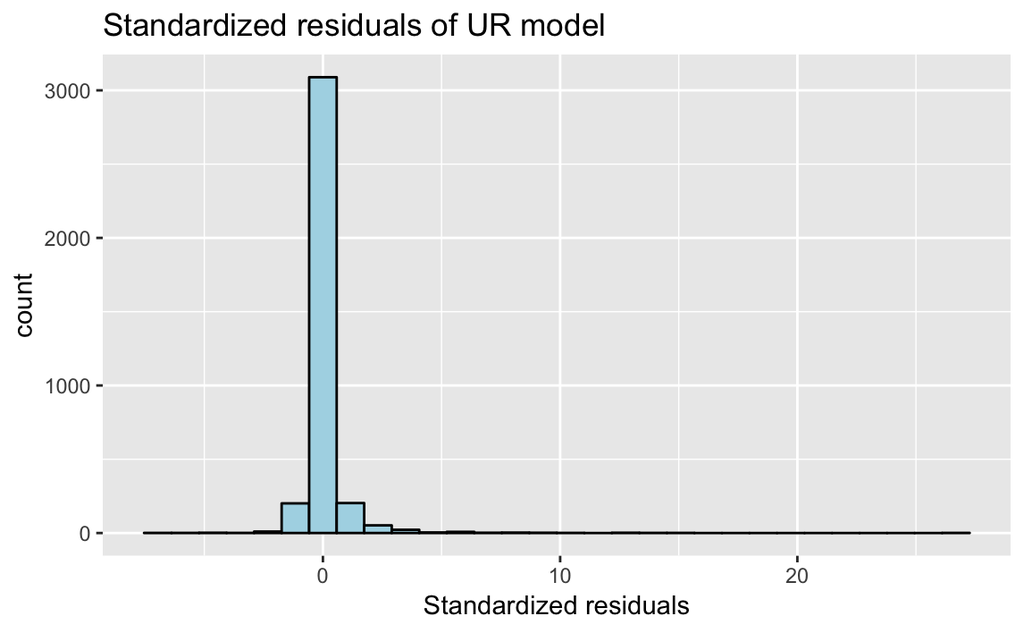

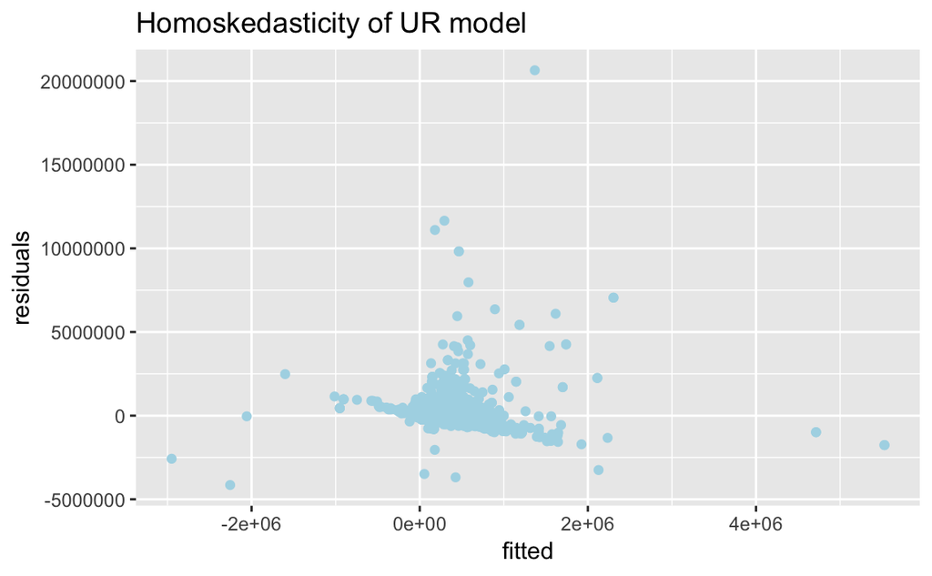

```r
suppressWarnings(plotResiduals(hh_profit, hh_profit_model_ur, "lightblue", "UR"))
```

#### Restricted model with significant variables (R1)

We pick the significant variables from the above unrestricted model and fit a restricted model.

```r
hh_profit_model_r1 <- lm(profit ~ reslan + ez + age + market + livstcd5 + livstcd6 + livstcd7 + livstcd10 +
                           equipTypeCount + eqcdown61 + cropcd5 + cropcd8 + cropcd11 + cropcd25 + cropcd29 +
                           rootcd7 + rootcd18 + rootcd20 + rootcd27 + rootcd33 + rootcd36,
                         data = hh_profit)
checkCorrVarAndTestHnull(hh_profit_model_r1)
```

```
===================== model summary =======================

Call:
lm(formula = profit ~ reslan + ez + age + market + livstcd5 +
    livstcd6 + livstcd7 + livstcd10 + equipTypeCount + eqcdown61 +
    cropcd5 + cropcd8 + cropcd11 + cropcd25 + cropcd29 + rootcd7 +
    rootcd18 + rootcd20 + rootcd27 + rootcd33 + rootcd36, data = hh_profit)

Residuals:
     Min       1Q   Median       3Q      Max
-4230445  -234684  -129489    33517 20721029

Coefficients:
                  Estimate Std. Error t value Pr(>|t|)
(Intercept)      2.166e+05  7.787e+04   2.781  0.00545 **
reslanAkan       4.694e+03  5.728e+04   0.082  0.93469
reslanEwe       -4.304e+04  7.487e+04  -0.575  0.56544
reslanGaAdangbe  2.707e+05  1.092e+05   2.480  0.01319 *
reslanDagbani   -1.701e+05  1.048e+05  -1.624  0.10448
reslanHausa     -1.750e+05  1.245e+05  -1.405  0.16015
reslanOther     -2.324e+05  8.018e+04  -2.899  0.00377 **
reslanUnknown   -6.183e+04  7.529e+04  -0.821  0.41159
ezForest         4.855e+04  3.988e+04   1.218  0.22347
ezSavannah       6.429e+04  4.706e+04   1.366  0.17194
age              1.676e+02  8.861e+02   0.189  0.84997
marketTRUE      -9.375e+04  3.902e+04  -2.403  0.01632 *
livstcd5         4.293e+04  5.847e+03   7.341 2.60e-13 ***
livstcd6         1.508e+05  4.643e+04   3.247  0.00118 **
livstcd7        -9.917e+00  5.336e+00  -1.859  0.06316 .
livstcd10       -8.339e+03  3.712e+03  -2.246  0.02476 *
equipTypeCount  -5.785e+04  2.463e+04  -2.349  0.01890 *
eqcdown61       -2.123e+06  2.644e+05  -8.031 1.30e-15 ***
cropcd5          3.344e+05  2.348e+05   1.424  0.15441
cropcd8         -1.430e+03  4.700e+02  -3.043  0.00236 **
cropcd11        -9.308e+04  1.711e+04  -5.441 5.65e-08 ***
cropcd25         1.002e+05  8.164e+03  12.278  < 2e-16 ***
cropcd29        -5.640e+03  3.735e+03  -1.510  0.13115
rootcd7          2.022e+04  7.682e+03   2.632  0.00852 **
rootcd18         2.408e+04  3.248e+03   7.413 1.53e-13 ***
rootcd20         4.457e+04  1.023e+04   4.356 1.36e-05 ***
```

[output cut: 39 more lines]

```
rootcd27 = 0
rootcd33 = 0
rootcd36 = 0

Model 1: restricted model
Model 2: profit ~ reslan + ez + age + market + livstcd5 + livstcd6 + livstcd7 +
    livstcd10 + equipTypeCount + eqcdown61 + cropcd5 + cropcd8 +
    cropcd11 + cropcd25 + cropcd29 + rootcd7 + rootcd18 + rootcd20 +
    rootcd27 + rootcd33 + rootcd36

  Res.Df        RSS Df  Sum of Sq      F    Pr(>F)
1   3612 2.4883e+15
2   3584 2.1750e+15 28 3.1327e+14 18.436 < 2.2e-16 ***
---
Signif. codes:  0 ‘***’ 0.001 ‘**’ 0.01 ‘*’ 0.05 ‘.’ 0.1 ‘ ’ 1
```

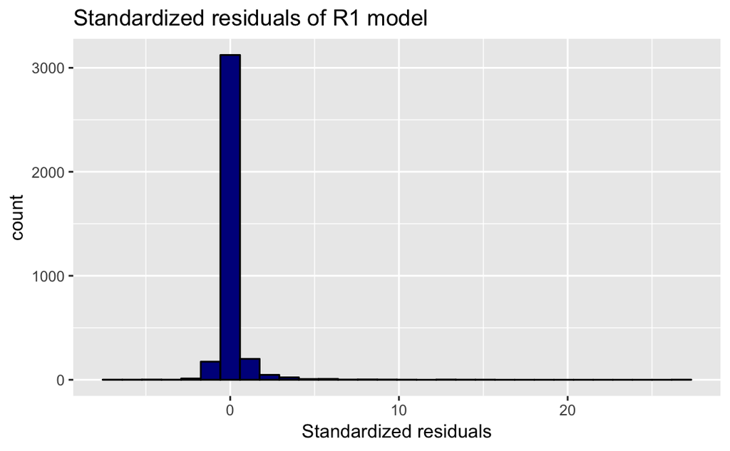

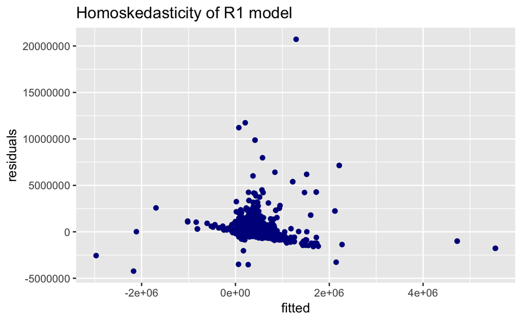

```r
suppressWarnings(plotResiduals(hh_profit, hh_profit_model_r1, "darkblue", "R1"))
```

#### Restricted model with top features from agricultural characteristics information (TOP)

We are also interested to see how will the model perform if fitted only with top 15 features from agricultural characteristics information. These top features are the variables that have higher correlation with profit, no matter it’s positive or negative correlation.

```r
hh_profit_agri <- hh_profit[, -c(2:14)] # get agricultural characteristics variables
all_correlations <- findAbsoluteCorrelation(hh_profit_agri)
```

```
the standard deviation is zerothe standard deviation is zerothe standard deviation is zero
```

```r
hh_profit_agri_topFeatures <- hh_profit[c("profit", all_correlations$colName[1:15])]
hh_profit_model_topfeatures <- lm(profit ~ . , data = hh_profit_agri_topFeatures)
checkCorrVarAndTestHnull(hh_profit_model_topfeatures)
```

```
===================== model summary =======================

Call:
lm(formula = profit ~ ., data = hh_profit_agri_topFeatures)

Residuals:
     Min       1Q   Median       3Q      Max
-4356876  -223572  -143826     9718 20824127

Coefficients:
                 Estimate Std. Error t value Pr(>|t|)
(Intercept)      226865.6    21550.4  10.527  < 2e-16 ***
cropcd25          84128.0     7257.6  11.592  < 2e-16 ***
rootcd18          23465.0     3380.7   6.941 4.60e-12 ***
rootcd20          44255.6    10409.3   4.252 2.18e-05 ***
rootTypeCount      2448.2     3722.7   0.658  0.51082
eqcdown61      -1969761.3   270480.3  -7.282 4.01e-13 ***
rootcd36          17450.2     5337.4   3.269  0.00109 **
livstcd5          32012.9     5377.6   5.953 2.89e-09 ***
equipTypeCount   -59648.8    23358.8  -2.554  0.01070 *
rootcd6            2489.4     1662.2   1.498  0.13432
rootcd7           16346.7     7718.2   2.118  0.03425 *
livstcd10         -8578.5     3735.6  -2.296  0.02171 *
rootcd30            276.4     2479.5   0.111  0.91124
rootcd5            1477.8     1296.6   1.140  0.25448
rootcd8             430.4      600.4   0.717  0.47355
livstcd2          -6932.1     5149.1  -1.346  0.17830
---
Signif. codes:  0 ‘***’ 0.001 ‘**’ 0.01 ‘*’ 0.05 ‘.’ 0.1 ‘ ’ 1

Residual standard error: 788200 on 3597 degrees of freedom
Multiple R-squared:  0.102, Adjusted R-squared:  0.09828
F-statistic: 27.25 on 15 and 3597 DF,  p-value: < 2.2e-16

===================== hypothesis test =====================
Linear hypothesis test

Hypothesis:
cropcd25 = 0
rootcd18 = 0
```

[output cut: 9 more lines]

```
rootcd30 = 0
rootcd5 = 0
rootcd8 = 0
livstcd2 = 0

Model 1: restricted model
Model 2: profit ~ cropcd25 + rootcd18 + rootcd20 + rootTypeCount + eqcdown61 +
    rootcd36 + livstcd5 + equipTypeCount + rootcd6 + rootcd7 +
    livstcd10 + rootcd30 + rootcd5 + rootcd8 + livstcd2

  Res.Df        RSS Df  Sum of Sq      F    Pr(>F)
1   3612 2.4883e+15
2   3597 2.2344e+15 15 2.5387e+14 27.246 < 2.2e-16 ***
---
Signif. codes:  0 ‘***’ 0.001 ‘**’ 0.01 ‘*’ 0.05 ‘.’ 0.1 ‘ ’ 1
```

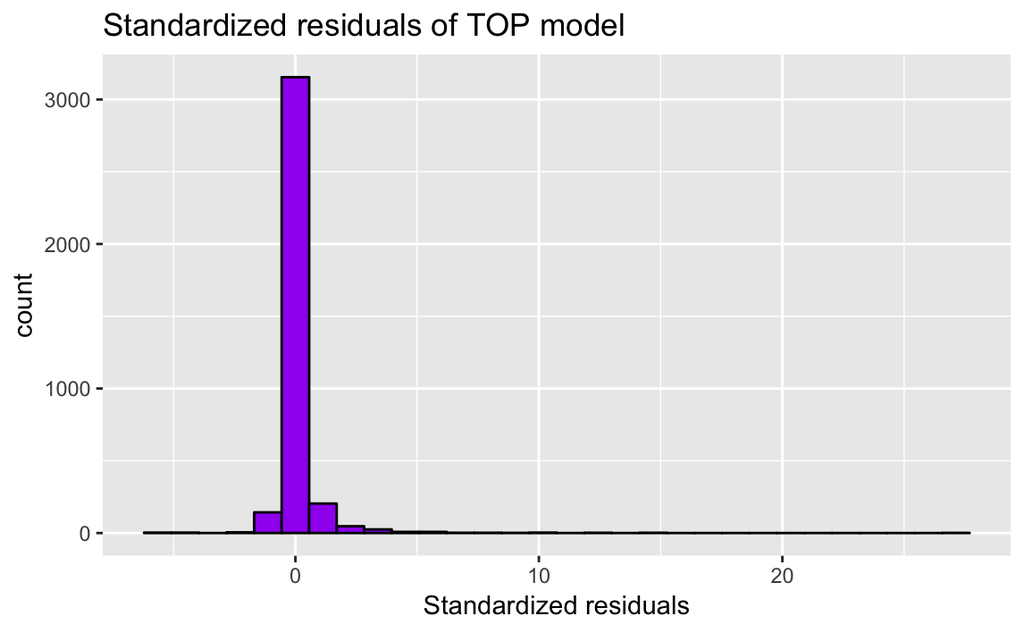

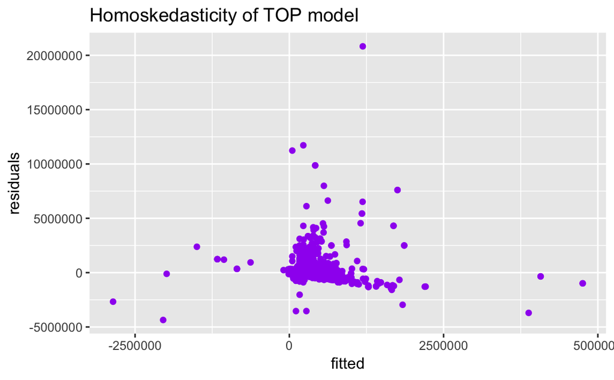

```r
suppressWarnings(plotResiduals(hh_profit, hh_profit_model_topfeatures, "purple", "TOP"))
```

#### Unrestricted model for rural area (RURAL)

Fit unrestricted model for rural area profit.

```r
hh_profit_model_rural <- lm(profit ~ .,
                            data = hh_profit_rural)
checkCorrVarAndTestHnull(hh_profit_model_rural)
```

```
===================== model summary =======================

Call:
lm(formula = profit ~ ., data = hh_profit_rural)

Residuals:
     Min       1Q   Median       3Q      Max
-4146964  -238546  -118235    46546 20643791

Coefficients: (5 not defined because of singularities)
                         Estimate Std. Error t value Pr(>|t|)
(Intercept)             3.165e+05  9.745e+04   3.248 0.001174 **
reslanAkan             -3.980e+04  6.191e+04  -0.643 0.520400
reslanEwe              -9.813e+04  8.080e+04  -1.214 0.224663
reslanGaAdangbe         2.437e+05  1.157e+05   2.107 0.035192 *
reslanDagbani          -1.920e+05  1.091e+05  -1.761 0.078401 .
reslanHausa            -1.617e+05  1.288e+05  -1.256 0.209224
reslanOther            -2.378e+05  8.432e+04  -2.820 0.004826 **
reslanUnknown          -1.122e+05  7.966e+04  -1.408 0.159184
ezForest                4.293e+04  4.459e+04   0.963 0.335781
ezSavannah              9.988e+04  5.515e+04   1.811 0.070223 .
loc5RuralForest                NA         NA      NA       NA
loc5RuralSavannah              NA         NA      NA       NA
femaleTRUE              1.203e+04  3.416e+04   0.352 0.724752
age                     3.770e+03  1.622e+03   2.324 0.020190 *
avgAge                 -2.234e+02  3.628e+03  -0.062 0.950902
maxAge                 -3.088e+03  1.867e+03  -1.654 0.098229 .
minAge                 -2.242e+03  2.456e+03  -0.913 0.361347
educBasicEducation     -3.337e+04  3.331e+04  -1.002 0.316476
educSecondaryEducation  7.066e+04  9.065e+04   0.780 0.435738
educTertiaryEducation  -8.169e+04  7.886e+04  -1.036 0.300339
educOther              -1.880e+05  1.760e+05  -1.068 0.285462
marketTRUE             -1.099e+05  4.196e+04  -2.620 0.008844 **
transportTRUE          -1.863e+04  3.045e+04  -0.612 0.540606
livstcdTypeCount       -7.444e+03  1.281e+04  -0.581 0.561133
livstcd1               -1.234e+04  3.862e+04  -0.320 0.749338
livstcd2               -2.516e+03  5.901e+03  -0.426 0.669861
livstcd3               -2.526e-01  5.366e-01  -0.471 0.637801
livstcd4               -1.312e-01  2.975e-01  -0.441 0.659209
livstcd5                4.394e+04  6.286e+03   6.989 3.30e-12 ***
```

[output cut: 203 more lines]

```
cropcd0           0        0        0        0        0        0
rootcd0           0        0        0        0        0        0
rootcd14          0        0        0        0        0        0
                  rootcd22 rootcd25 rootcd26 rootcd27 rootcd29 rootcd30
loc5RuralForest   0        0        0        0        0        0
loc5RuralSavannah 0        0        0        0        0        0
cropcd0           0        0        0        0        0        0
rootcd0           0        0        0        0        0        0
rootcd14          0        0        0        0        0        0
                  rootcd31 rootcd33 rootcd34 rootcd35 rootcd36
loc5RuralForest   0        0        0        0        0
loc5RuralSavannah 0        0        0        0        0
cropcd0           0        0        0        0        0
rootcd0           0        0        0        0        0
rootcd14          0        0        0        0        0
```

```
There are correlated variables. See above model alias.
```

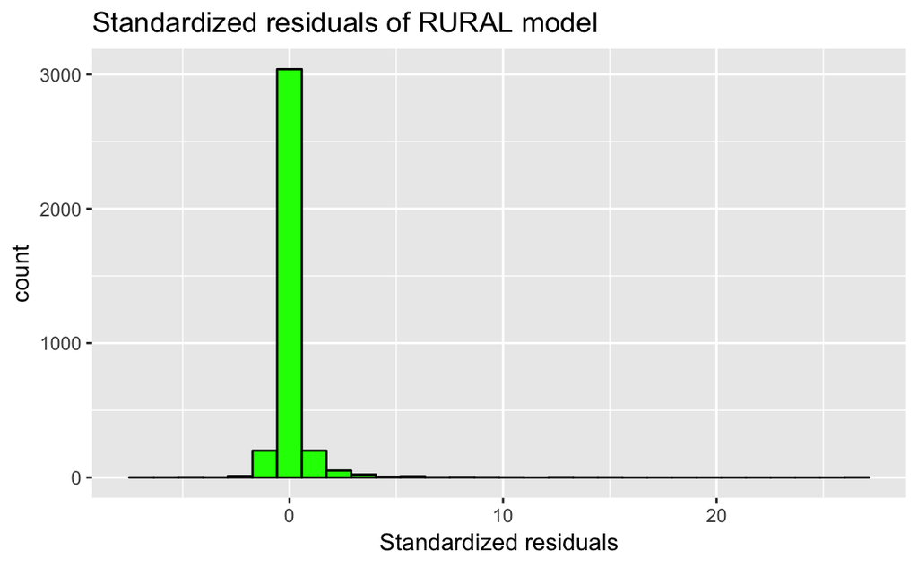

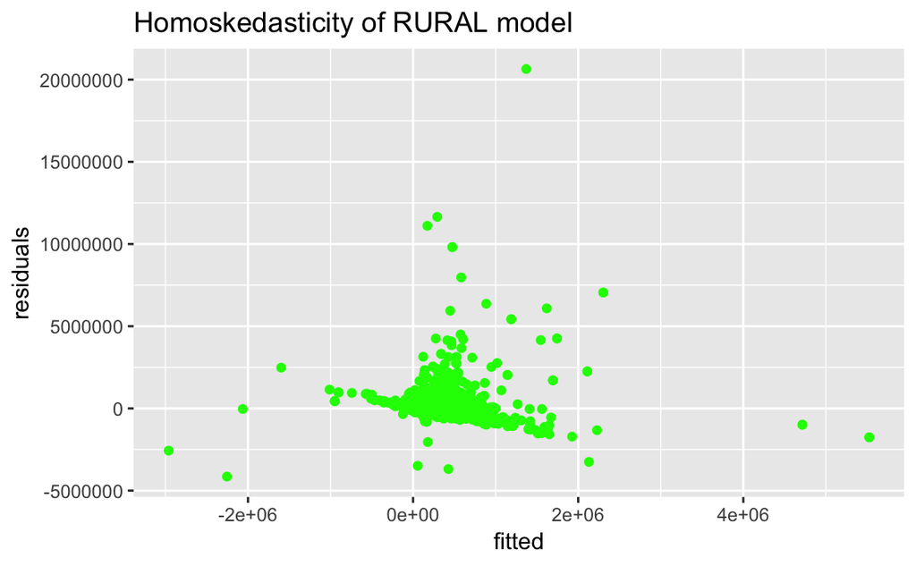

```r
suppressWarnings(plotResiduals(hh_profit_rural, hh_profit_model_rural, "green", "RURAL"))
```

#### Unrestricted model for urban area

Fit unrestricted model for urban area profit. We notice that the adjusted R squared is really low, and there are a lot of correlated variable. By looking at data size, we see that there are less observations than variables for urban are profit data. So we don’t have enough data to fit a model.

```r
hh_profit_model_urban <- lm(profit ~ .,
                            data = hh_profit_urban)
checkCorrVarAndTestHnull(hh_profit_model_urban)
```

```
===================== model summary =======================

Call:
lm(formula = profit ~ ., data = hh_profit_urban)

Residuals:
    Min      1Q  Median      3Q     Max
-609766  -62750       0   43147  709516

Coefficients: (53 not defined because of singularities)
                         Estimate Std. Error t value Pr(>|t|)
(Intercept)            -3.969e+05  1.048e+06  -0.379    0.712
reslanAkan              1.276e+05  7.214e+05   0.177    0.863
reslanUnknown           2.854e+05  8.071e+05   0.354    0.730
ezSavannah             -9.612e+05  6.879e+05  -1.397    0.188
femaleTRUE             -1.599e+04  2.718e+05  -0.059    0.954
age                     1.074e+04  1.302e+04   0.825    0.425
avgAge                 -1.654e+04  3.730e+04  -0.443    0.665
maxAge                  6.680e+03  1.790e+04   0.373    0.716
minAge                  4.451e+02  2.880e+04   0.015    0.988
educBasicEducation      3.686e+05  3.712e+05   0.993    0.340
educSecondaryEducation  2.229e+05  8.876e+05   0.251    0.806
educTertiaryEducation   9.755e+02  5.419e+05   0.002    0.999
marketTRUE              1.075e+06  5.401e+05   1.989    0.070 .
transportTRUE                  NA         NA      NA       NA
livstcdTypeCount       -8.311e+05  8.671e+05  -0.959    0.357
livstcd1                       NA         NA      NA       NA
livstcd2                       NA         NA      NA       NA
livstcd3                9.080e+04  1.196e+05   0.759    0.462
livstcd4                5.326e+04  1.320e+05   0.403    0.694
livstcd5                1.049e+05  6.914e+04   1.517    0.155
livstcd6                       NA         NA      NA       NA
livstcd7                7.646e+04  7.178e+04   1.065    0.308
livstcd8                8.764e+04  9.539e+04   0.919    0.376
livstcd9                       NA         NA      NA       NA
livstcd10                      NA         NA      NA       NA
livstcd11                      NA         NA      NA       NA
livstcd12                      NA         NA      NA       NA
equipTypeCount          7.001e+05  1.150e+06   0.609    0.554
eqcdown21                      NA         NA      NA       NA
```

[output cut: 288 more lines]

```
eqcdown21       0
eqcdown22       0
eqcdown31       0
eqcdown51       0
eqcdown61       0
eqcdown62       0
eqcdown63       0
eqcdown64       0
cropcd0         0
cropcd2         0
cropcd3         0
cropcd4         0
cropcd5         0
cropcd6         0
 [ reached getOption("max.print") -- omitted 31 rows ]
```

```
There are correlated variables. See above model alias.
```

```r
# check data size
dim(hh_profit_urban)
```

```
[1] 56 94
```

#### Restricted model with only education and local characteristic information (R2, R3)

We also want to see how education and local characteristic info alone influence profit. Looking at hypothesis test result, loc5 and loc3 are correlated with other variables. So remove them and fit model again. Looking at the summary, there are not many significant variables, also the R squared is very low.

```r
hh_profit_model_r2 <- lm(profit ~ educ + ez + loc2 + loc5 + loc3 + market + transport,
                         data = hh_profit)
checkCorrVarAndTestHnull(hh_profit_model_r2)
```

```
===================== model summary =======================

Call:
lm(formula = profit ~ educ + ez + loc2 + loc5 + loc3 + market +
    transport, data = hh_profit)

Residuals:
     Min       1Q   Median       3Q      Max
-6686068  -259175  -173421     3700 21648271

Coefficients: (3 not defined because of singularities)
                         Estimate Std. Error t value Pr(>|t|)
(Intercept)             341148.54  271694.77   1.256  0.20933
educBasicEducation         604.85   31312.81   0.019  0.98459
educSecondaryEducation   20078.89   88658.86   0.226  0.82085
educTertiaryEducation  -114169.37   78495.67  -1.454  0.14590
educOther              -245371.94  181893.76  -1.349  0.17743
ezForest                 79473.13  294500.56   0.270  0.78729
ezSavannah              -25449.92   44857.89  -0.567  0.57051
loc2Rural               -31347.21  266430.71  -0.118  0.90635
loc5RuralCoastal               NA         NA      NA       NA
loc5RuralForest            -36.17  292751.08   0.000  0.99990
loc5RuralSavannah              NA         NA      NA       NA
loc3Rural                      NA         NA      NA       NA
marketTRUE             -110715.56   41813.82  -2.648  0.00814 **
transportTRUE           -23157.10   30171.81  -0.768  0.44283
---
Signif. codes:  0 ‘***’ 0.001 ‘**’ 0.01 ‘*’ 0.05 ‘.’ 0.1 ‘ ’ 1

Residual standard error: 828500 on 3602 degrees of freedom
Multiple R-squared:  0.006371,  Adjusted R-squared:  0.003612
F-statistic: 2.309 on 10 and 3602 DF,  p-value: 0.01058

===================== model alias =========================
Model :
profit ~ educ + ez + loc2 + loc5 + loc3 + market + transport

Complete :
                  (Intercept) educBasicEducation educSecondaryEducation
loc5RuralCoastal   1           0                  0
loc5RuralSavannah -1           0                  0
loc3Rural          0           0                  0
                  educTertiaryEducation educOther ezForest ezSavannah
loc5RuralCoastal   0                     0        -1       -1
loc5RuralSavannah  0                     0         1        1
loc3Rural          0                     0         0        0
                  loc2Rural loc5RuralForest marketTRUE transportTRUE
loc5RuralCoastal   0         0               0          0
loc5RuralSavannah  1        -1               0          0
loc3Rural          1         0               0          0
```

```
There are correlated variables. See above model alias.
```

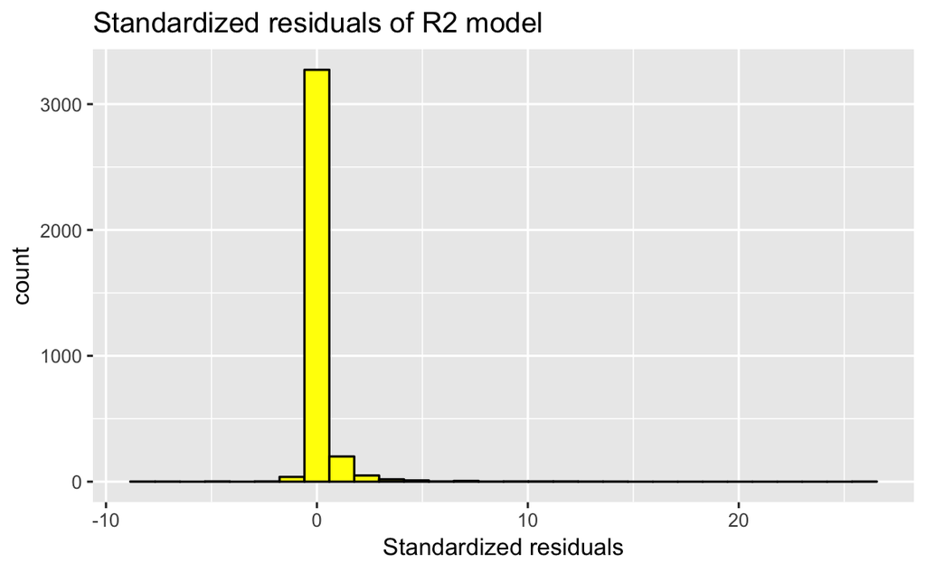

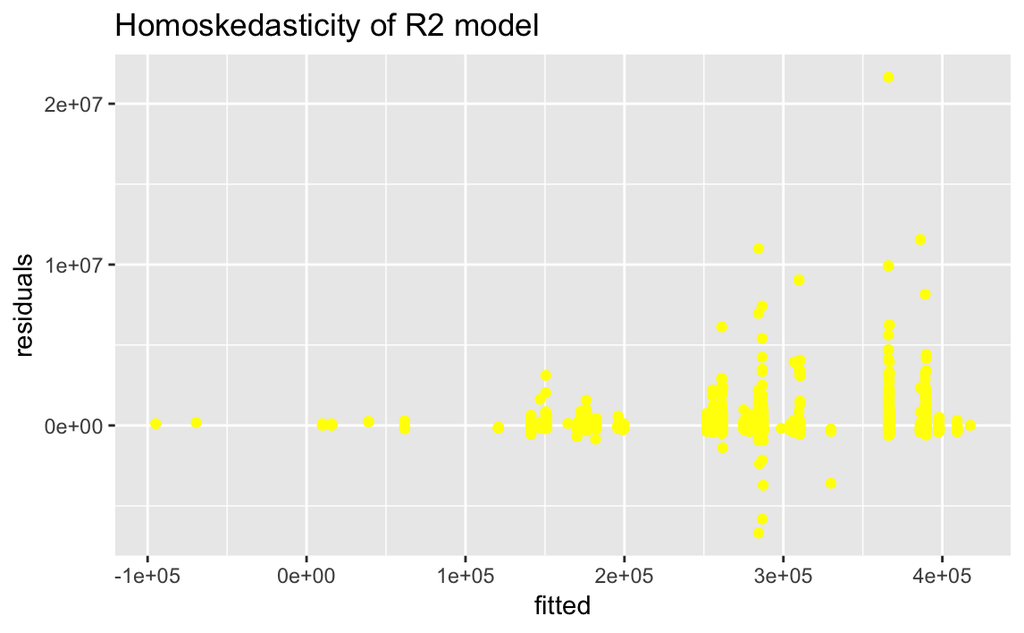

```r
suppressWarnings(plotResiduals(hh_profit, hh_profit_model_r2, "yellow", "R2"))
```

```r
# remove loc5 and loc3 and fit model again
hh_profit_model_r3 <- lm(profit ~ educ + ez + loc2 + market + transport,
                         data = hh_profit)
checkCorrVarAndTestHnull(hh_profit_model_r3)
```

```
===================== model summary =======================

Call:
lm(formula = profit ~ educ + ez + loc2 + market + transport,
    data = hh_profit)

Residuals:
     Min       1Q   Median       3Q      Max
-6686068  -259175  -173421     3700 21648271

Coefficients:
                        Estimate Std. Error t value Pr(>|t|)
(Intercept)             341178.5   122474.1   2.786  0.00537 **
educBasicEducation         604.7    31295.3   0.019  0.98458
educSecondaryEducation   20079.0    88642.2   0.227  0.82081
educTertiaryEducation  -114169.3    78481.0  -1.455  0.14583
educOther              -245371.9   181867.3  -1.349  0.17736
ezForest                 79437.1    39472.3   2.012  0.04424 *
ezSavannah              -25450.3    44729.0  -0.569  0.56940
loc2Rural               -31377.0   112961.1  -0.278  0.78121
marketTRUE             -110716.1    41581.9  -2.663  0.00779 **
transportTRUE           -23157.1    30167.4  -0.768  0.44276
---
Signif. codes:  0 ‘***’ 0.001 ‘**’ 0.01 ‘*’ 0.05 ‘.’ 0.1 ‘ ’ 1

Residual standard error: 828400 on 3603 degrees of freedom
Multiple R-squared:  0.006371,  Adjusted R-squared:  0.003889
F-statistic: 2.567 on 9 and 3603 DF,  p-value: 0.006086

===================== hypothesis test =====================
Linear hypothesis test

Hypothesis:
educBasicEducation = 0
educSecondaryEducation = 0
educTertiaryEducation = 0
educOther = 0
ezForest = 0
ezSavannah = 0
loc2Rural = 0
marketTRUE = 0
transportTRUE = 0

Model 1: restricted model
Model 2: profit ~ educ + ez + loc2 + market + transport

  Res.Df        RSS Df  Sum of Sq      F   Pr(>F)
1   3612 2.4883e+15
2   3603 2.4724e+15  9 1.5852e+13 2.5668 0.006086 **
---
Signif. codes:  0 ‘***’ 0.001 ‘**’ 0.01 ‘*’ 0.05 ‘.’ 0.1 ‘ ’ 1
```

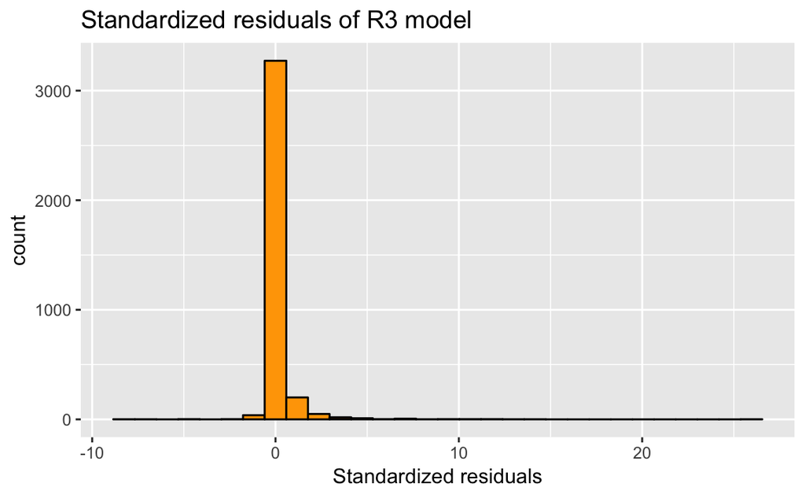

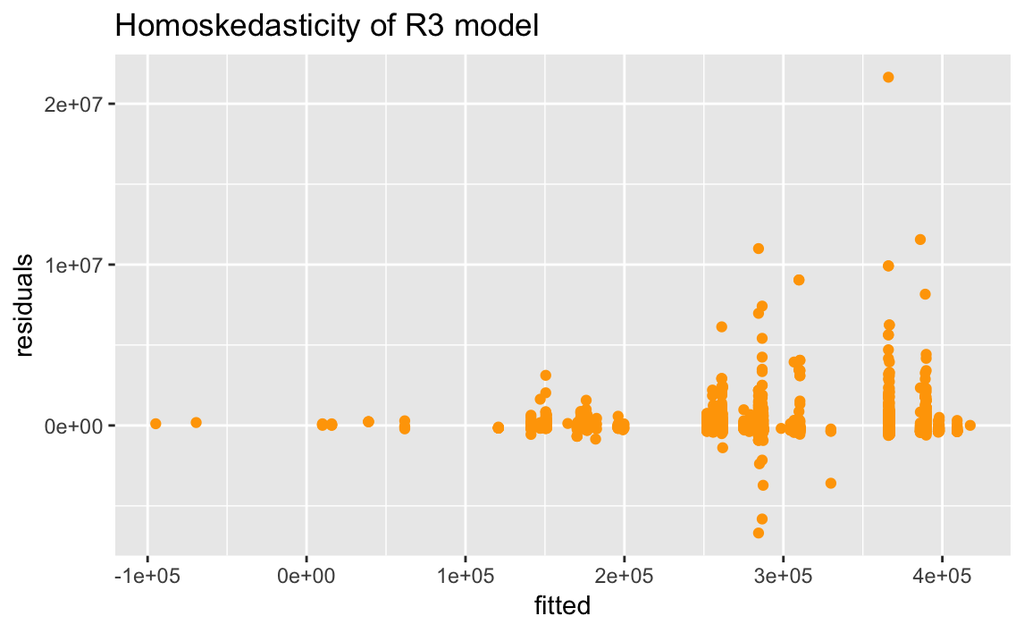

```r
suppressWarnings(plotResiduals(hh_profit, hh_profit_model_r3, "orange", "R3"))
```

#### Restricted model with educ * age (R4)

Although the education in the above model is not significant, we are curious to see if educ and age together would become significant. So we fit a model with `educ * age`. However, looking at the summary it’s still not significant.

```r
hh_profit_model_r4 <- lm(profit ~ educ * age + female + ez + loc2 + market + transport,
                         data = hh_profit)
checkCorrVarAndTestHnull(hh_profit_model_r4)
```

```
===================== model summary =======================

Call:
lm(formula = profit ~ educ * age + female + ez + loc2 + market +
    transport, data = hh_profit)

Residuals:
     Min       1Q   Median       3Q      Max
-6693082  -260609  -173405     4360 21635925

Coefficients:
                             Estimate Std. Error t value Pr(>|t|)
(Intercept)                 363514.37  136714.01   2.659  0.00787 **
educBasicEducation          -43926.23  108243.80  -0.406  0.68491
educSecondaryEducation      206525.08  346672.42   0.596  0.55139
educTertiaryEducation      -221002.20  358817.33  -0.616  0.53799
educOther                    19470.37  903976.83   0.022  0.98282
age                            -75.88    1130.08  -0.067  0.94647
femaleTRUE                  -35363.11   33340.55  -1.061  0.28891
ezForest                     78569.77   39620.05   1.983  0.04743 *
ezSavannah                  -32145.59   45435.95  -0.707  0.47931
loc2Rural                   -37651.00  113301.97  -0.332  0.73968
marketTRUE                 -106856.37   41927.77  -2.549  0.01086 *
transportTRUE               -19935.82   30302.98  -0.658  0.51066
educBasicEducation:age         866.44    2429.91   0.357  0.72143
educSecondaryEducation:age   -5229.05    8809.74  -0.594  0.55285
educTertiaryEducation:age     2087.10    7643.66   0.273  0.78483
educOther:age                -5491.26   17510.71  -0.314  0.75385
---
Signif. codes:  0 ‘***’ 0.001 ‘**’ 0.01 ‘*’ 0.05 ‘.’ 0.1 ‘ ’ 1

Residual standard error: 828900 on 3597 degrees of freedom
Multiple R-squared:  0.006882,  Adjusted R-squared:  0.002741
F-statistic: 1.662 on 15 and 3597 DF,  p-value: 0.0515

===================== hypothesis test =====================
Linear hypothesis test

Hypothesis:
educBasicEducation = 0
```

[output cut: 8 more lines]

```
marketTRUE = 0
transportTRUE = 0
educBasicEducation:age = 0
educSecondaryEducation:age = 0
educTertiaryEducation:age = 0
educOther:age = 0

Model 1: restricted model
Model 2: profit ~ educ * age + female + ez + loc2 + market + transport

  Res.Df        RSS Df  Sum of Sq      F Pr(>F)
1   3612 2.4883e+15
2   3597 2.4711e+15 15 1.7125e+13 1.6618 0.0515 .
---
Signif. codes:  0 ‘***’ 0.001 ‘**’ 0.01 ‘*’ 0.05 ‘.’ 0.1 ‘ ’ 1
```

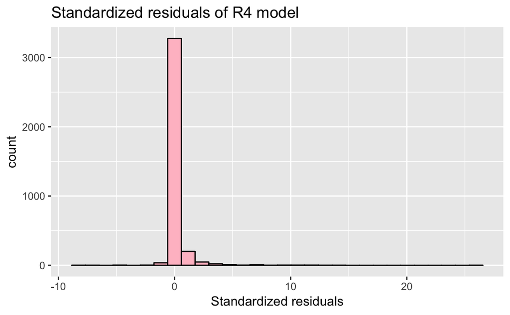

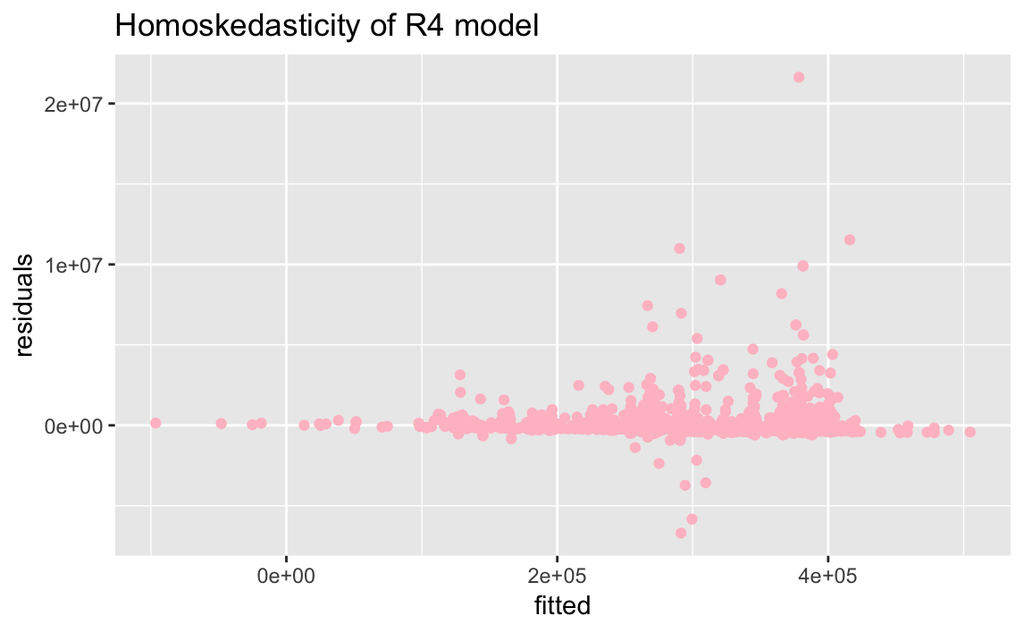

```r
suppressWarnings(plotResiduals(hh_profit, hh_profit_model_r4, "pink", "R4"))
```